# Supply Chain Data - FMCG in Instant noodles

### Business Context:

A fast-moving consumer goods (FMCG) company that entered the instant noodles market two years ago is facing challenges in balancing demand and supply across its warehouses nationwide. In some regions, demand far exceeds supply, while in others, excess inventory is leading to wastage and higher costs. This mismatch results in significant inventory losses and missed sales opportunities. To remain competitive and profitable in the highly dynamic FMCG sector, the company needs a data-driven approach to optimize its supply chain and align production with regional demand patterns.

### Objective:

As a data scientist, you are tasked with building a predictive model using historical sales and supply data to determine the optimum quantity of product to ship to each warehouse. Additionally, analyzing demand patterns across different regions will help management design targeted advertisement campaigns. Solving this problem will enable the company to minimize inventory costs, reduce stockouts, and drive higher sales through better demand forecasting and efficient supply chain management

## **Data Dictionary**:

The dataset contains information about the historical sales patterns. The detailed data dictionary is given below:

- `Ware_house_ID`: Product warehouse ID
- `WH_Manager_ID`: Employee ID of warehouse manager
- `Location_type`: Location of the warehouse, like in a city or a village
- `WH_capacity_siz`: Storage capacity size of the warehouse
- `zone`: Zone of the warehouse
- `WH_regional_zone`: Regional zone of the warehouse under each zone
- `num_refill_req_l3m`: Number of times refilling has been done in the last 3 months
- `transport_issue_l1y`: Any transport issue, like an accident or goods stolen, reported in the last year
- `Competitor_in_mkt`: Number of instant noodles competitors in the market
- `retail_shop_num`: Number of retail shops that sell the product under the warehouse area
- `wh_owner_type`: Company owns the warehouse, or they have rented the warehouse
- `distributor_num`: Number of distributors working between the warehouse and retail shops
- `flood_impacted`: Warehouse is in the flood-impacted area indicator
- `flood_proof`: Warehouse is flood-proof. Like storage is at some height, not directly on the ground
- `electric_supply`: The Warehouse has an electric backup, like a generator, so they can run the warehouse in load shedding
- `dist_from_hub`: Distance between the warehouse to the production hub in Kms
- `workers_num`: Number of workers working in the warehouse
- `wh_est_year`: Warehouse established year
- `storage_issue_reported_l3m`: Warehouse reported a storage issue to the corporate office in the last 3 months. Like rats, fungus due to moisture, etc.
- `temp_reg_mach`: Warehouse has a temperature regulating machine indicator
- `approved_wh_govt_certificate`: What kind of standard certificate has been issued to the warehouse from the government regulatory body
- `wh_breakdown_l3m`: Number of times the warehouse faced a breakdown in the last 3 months. Like a strike by workers, a flood, or an electrical failure
- `govt_check_l3m`: Number of times government officers have visited the warehouse to check the quality and expiry of stored food in the last 3 months
- `product_wg_ton`: Product has been shipped in the last 3 months. Weight is in tons

```python
#To work on data manipulation
import pandas as pd
import numpy as np

# To help with visualization
import seaborn as sns
%matplotlib inline
import matplotlib.pyplot as plt

# For missing values imputation
from sklearn.impute import SimpleImputer
```

```python
from google.colab import drive
drive.mount('/content/Drive')
```

```python
path="/content/Drive/MyDrive/supply_chain_data.csv"
data = pd.read_csv(path)
```

## **Overview of the Data**

### View the first five rows

```python
data.head() # Shows first 5 rows of data
```

|  | Ware_house_ID | WH_Manager_ID | Location_type | WH_capacity_size | zone | WH_regional_zone | num_refill_req_l3m | transport_issue_l1y | Competitor_in_mkt | retail_shop_num | ... | electric_supply | dist_from_hub | workers_num | wh_est_year | storage_issue_reported_l3m | temp_reg_mach | approved_wh_govt_certificate | wh_breakdown_l3m | govt_check_l3m | product_wg_ton |
| --- | --- | --- | --- | --- | --- | --- | --- | --- | --- | --- | --- | --- | --- | --- | --- | --- | --- | --- | --- | --- | --- |
| 0 | WH_100000 | EID_50000 | Urban | Small | West | Zone 6 | 3 | 1 | 2 | 4651 | ... | 1 | 91 | 29.0 | NaN | 13 | 0 | A | 5 | 15 | 17115 |
| 1 | WH_100001 | EID_50001 | Rural | Large | North | Zone 5 | 0 | 0 | 4 | 6217 | ... | 1 | 210 | 31.0 | NaN | 4 | 0 | A | 3 | 17 | 5074 |
| 2 | WH_100002 | EID_50002 | Rural | Mid | South | Zone 2 | 1 | 0 | 4 | 4306 | ... | 0 | 161 | 37.0 | NaN | 17 | 0 | A | 6 | 22 | 23137 |
| 3 | WH_100003 | EID_50003 | Rural | Mid | North | Zone 3 | 7 | 4 | 2 | 6000 | ... | 0 | 103 | 21.0 | NaN | 17 | 1 | A+ | 3 | 27 | 22115 |
| 4 | WH_100004 | EID_50004 | Rural | Large | North | Zone 5 | 3 | 1 | 2 | 4740 | ... | 1 | 112 | 25.0 | 2009.0 | 18 | 0 | C | 6 | 24 | 24071 |

5 rows × 24 columns

### View the last five rows

```python
data.tail() # Shows last 5 rows of data
```

|  | Ware_house_ID | WH_Manager_ID | Location_type | WH_capacity_size | zone | WH_regional_zone | num_refill_req_l3m | transport_issue_l1y | Competitor_in_mkt | retail_shop_num | ... | electric_supply | dist_from_hub | workers_num | wh_est_year | storage_issue_reported_l3m | temp_reg_mach | approved_wh_govt_certificate | wh_breakdown_l3m | govt_check_l3m | product_wg_ton |
| --- | --- | --- | --- | --- | --- | --- | --- | --- | --- | --- | --- | --- | --- | --- | --- | --- | --- | --- | --- | --- | --- |
| 24995 | WH_124995 | EID_74995 | Rural | Small | North | Zone 1 | 3 | 0 | 4 | 5390 | ... | 1 | 142 | 34.0 | 2005.0 | 22 | 1 | A | 2 | 30 | 32093 |
| 24996 | WH_124996 | EID_74996 | Rural | Mid | West | Zone 2 | 6 | 0 | 4 | 4490 | ... | 1 | 130 | 28.0 | 2012.0 | 10 | 0 | B | 4 | 18 | 12114 |
| 24997 | WH_124997 | EID_74997 | Urban | Large | South | Zone 5 | 7 | 0 | 2 | 5403 | ... | 1 | 147 | NaN | NaN | 23 | 0 | B+ | 5 | 25 | 27080 |
| 24998 | WH_124998 | EID_74998 | Rural | Small | North | Zone 1 | 1 | 0 | 2 | 10562 | ... | 1 | 60 | 25.0 | NaN | 18 | 0 | A | 6 | 30 | 25093 |
| 24999 | WH_124999 | EID_74999 | Rural | Mid | West | Zone 4 | 8 | 2 | 4 | 5664 | ... | 1 | 239 | 39.0 | 2019.0 | 4 | 0 | B+ | 2 | 11 | 5058 |

5 rows × 24 columns

## Understanding the shape of the data

```python
data.shape # Shows no of rows and columns
```

```
(25000, 24)
```

- Data has 25000 rows and 24 columns

### Understanding the statistical summary of data

```python
data.describe().T # Statistical summary of data
```

|  | count | mean | std | min | 25% | 50% | 75% | max |
| --- | --- | --- | --- | --- | --- | --- | --- | --- |
| num_refill_req_l3m | 25000.0 | 4.089040 | 2.606612 | 0.0 | 2.0 | 4.0 | 6.0 | 8.0 |
| transport_issue_l1y | 25000.0 | 0.773680 | 1.199449 | 0.0 | 0.0 | 0.0 | 1.0 | 5.0 |
| Competitor_in_mkt | 25000.0 | 3.104200 | 1.141663 | 0.0 | 2.0 | 3.0 | 4.0 | 12.0 |
| retail_shop_num | 25000.0 | 4985.711560 | 1052.825252 | 1821.0 | 4313.0 | 4859.0 | 5500.0 | 11008.0 |
| distributor_num | 25000.0 | 42.418120 | 16.064329 | 15.0 | 29.0 | 42.0 | 56.0 | 70.0 |
| flood_impacted | 25000.0 | 0.098160 | 0.297537 | 0.0 | 0.0 | 0.0 | 0.0 | 1.0 |
| flood_proof | 25000.0 | 0.054640 | 0.227281 | 0.0 | 0.0 | 0.0 | 0.0 | 1.0 |
| electric_supply | 25000.0 | 0.656880 | 0.474761 | 0.0 | 0.0 | 1.0 | 1.0 | 1.0 |
| dist_from_hub | 25000.0 | 163.537320 | 62.718609 | 55.0 | 109.0 | 164.0 | 218.0 | 271.0 |
| workers_num | 24010.0 | 28.944398 | 7.872534 | 10.0 | 24.0 | 28.0 | 33.0 | 98.0 |
| wh_est_year | 13119.0 | 2009.383185 | 7.528230 | 1996.0 | 2003.0 | 2009.0 | 2016.0 | 2023.0 |
| storage_issue_reported_l3m | 25000.0 | 17.130440 | 9.161108 | 0.0 | 10.0 | 18.0 | 24.0 | 39.0 |
| temp_reg_mach | 25000.0 | 0.303280 | 0.459684 | 0.0 | 0.0 | 0.0 | 1.0 | 1.0 |
| wh_breakdown_l3m | 25000.0 | 3.482040 | 1.690335 | 0.0 | 2.0 | 3.0 | 5.0 | 6.0 |
| govt_check_l3m | 25000.0 | 18.812280 | 8.632382 | 1.0 | 11.0 | 21.0 | 26.0 | 32.0 |
| product_wg_ton | 25000.0 | 22102.632920 | 11607.755077 | 2065.0 | 13059.0 | 22101.0 | 30103.0 | 55151.0 |

## Check the data types of the columns for the dataset

```python
data.info() # Gives a brief of data like the no of entries per each column and data types
```

```
<class 'pandas.core.frame.DataFrame'>
RangeIndex: 25000 entries, 0 to 24999
Data columns (total 24 columns):
 #   Column                        Non-Null Count  Dtype
---  ------                        --------------  -----
 0   Ware_house_ID                 25000 non-null  object
 1   WH_Manager_ID                 25000 non-null  object
 2   Location_type                 25000 non-null  object
 3   WH_capacity_size              25000 non-null  object
 4   zone                          25000 non-null  object
 5   WH_regional_zone              25000 non-null  object
 6   num_refill_req_l3m            25000 non-null  int64
 7   transport_issue_l1y           25000 non-null  int64
 8   Competitor_in_mkt             25000 non-null  int64
 9   retail_shop_num               25000 non-null  int64
```

[output cut: 16 more lines]

- The data seems to show **missing values** in **3** attributes namely `workers_num`, `wh_est_year`, `approved_wh_govt_certificate`.
- **Numerical variables** include total **14** variables, `num_refill_req_l3m`,`transport_issue_l1y`, `Competitor_in_mkt`,`retail_shop_num`, `distributor_num`, `flood_impacted` , `flood_proof`, `electric_supply`, `dist_from_hub`, `storage_issue_reported_l3m`, `temp_reg_mach`, `wh_breakdown_l3m`, `govt_check_l3m`, `product_wg_ton`
- **Categorical columns** include total **8** variables `namely ware_house_ID`, `WH_Manager_ID`, `Location_type`, `WH_capacity_size`, `zone`, `WH_regional_zone`, `wh_owner_type`, `approved_wh_govt_certificate`
- Float variables are `workers_num`,`wh_est_year` which can be changed to Date time format

## **Checking for Duplicates in the Data**

```python
data.duplicated().sum()
```

```
np.int64(0)
```

- There seems to be no duplicate values in the data

## **Checking and Treating Missing values in the Data**

```python
data.isnull().sum()
```

|  | 0 |
| --- | --- |
| Ware_house_ID | 0 |
| WH_Manager_ID | 0 |
| Location_type | 0 |
| WH_capacity_size | 0 |
| zone | 0 |
| WH_regional_zone | 0 |
| num_refill_req_l3m | 0 |
| transport_issue_l1y | 0 |
| Competitor_in_mkt | 0 |
| retail_shop_num | 0 |
| wh_owner_type | 0 |
| distributor_num | 0 |
| flood_impacted | 0 |
| flood_proof | 0 |
| electric_supply | 0 |
| dist_from_hub | 0 |
| workers_num | 990 |
| wh_est_year | 11881 |
| storage_issue_reported_l3m | 0 |
| temp_reg_mach | 0 |
| approved_wh_govt_certificate | 908 |
| wh_breakdown_l3m | 0 |
| govt_check_l3m | 0 |
| product_wg_ton | 0 |

**dtype:** int64

- There seems to be 3 features showing the missing values in the data, `workers_num`,`wh_est_year`, `approved_wh_govt_certificate`
- These can be replaced with **mode** for categorical variables like approved_wh_govt_Certificate and **median/central value** for numerical variables like workers_num and wh_est_year

### **Treating Missing values in the Data**

```python
import pandas as pd
from sklearn.impute import KNNImputer
from scipy.stats import pearsonr

# Step 1: Convert float years to integers
data['wh_est_year'] = data['wh_est_year'].astype('float')

# Step 2: Select features relevant for imputation
features_for_imputation = ['wh_est_year', 'workers_num', 'dist_from_hub', 'retail_shop_num']

# Step 3: Apply KNN imputer
imputer = KNNImputer(n_neighbors=5)
data[features_for_imputation] = imputer.fit_transform(data[features_for_imputation])

# Step 4: Create warehouse_age
current_year = 2026
data['warehouse_age'] = current_year - data['wh_est_year'].round().astype(int)

# Step 5: Test significance of warehouse_age against product weight
subset = data[['warehouse_age', 'product_wg_ton']].dropna()
corr, pval = pearsonr(subset['warehouse_age'], subset['product_wg_ton'])
print("Correlation:", corr, "P-value:", pval)

# Step 6: Drop original wh_est_year if not needed
data = data.drop('wh_est_year', axis=1)

# Step 7: Check for remaining missing values
display(data.isnull().sum())
```

```
Correlation: 0.5640033620292368 P-value: 0.0
```

|  | 0 |
| --- | --- |
| Ware_house_ID | 0 |
| WH_Manager_ID | 0 |
| Location_type | 0 |
| WH_capacity_size | 0 |
| zone | 0 |
| WH_regional_zone | 0 |
| num_refill_req_l3m | 0 |
| transport_issue_l1y | 0 |
| Competitor_in_mkt | 0 |
| retail_shop_num | 0 |
| wh_owner_type | 0 |
| distributor_num | 0 |
| flood_impacted | 0 |
| flood_proof | 0 |
| electric_supply | 0 |
| dist_from_hub | 0 |
| workers_num | 0 |
| storage_issue_reported_l3m | 0 |
| temp_reg_mach | 0 |
| approved_wh_govt_certificate | 908 |
| wh_breakdown_l3m | 0 |
| govt_check_l3m | 0 |
| product_wg_ton | 0 |
| warehouse_age | 0 |

**dtype:** int64

#### Filling missing values of categorical column - 'approved_wh_govt_certificate'

```python
# filling missing values of categorical column in approved_wh_govt_certificate with the business-defined category

data['approved_wh_govt_certificate'] = data['approved_wh_govt_certificate'].fillna('Applied_Not_Received')
display(data.isnull().sum())
```

|  | 0 |
| --- | --- |
| Ware_house_ID | 0 |
| WH_Manager_ID | 0 |
| Location_type | 0 |
| WH_capacity_size | 0 |
| zone | 0 |
| WH_regional_zone | 0 |
| num_refill_req_l3m | 0 |
| transport_issue_l1y | 0 |
| Competitor_in_mkt | 0 |
| retail_shop_num | 0 |
| wh_owner_type | 0 |
| distributor_num | 0 |
| flood_impacted | 0 |
| flood_proof | 0 |
| electric_supply | 0 |
| dist_from_hub | 0 |
| workers_num | 0 |
| storage_issue_reported_l3m | 0 |
| temp_reg_mach | 0 |
| approved_wh_govt_certificate | 0 |
| wh_breakdown_l3m | 0 |
| govt_check_l3m | 0 |
| product_wg_ton | 0 |
| warehouse_age | 0 |

**dtype:** int64

## **Changing the Data types**

- Now we change the data types of workers number to numerical for better analysis.
- Also we check if all variables show correct datatypes and count to proceed for data modelling.

```python
#Changing the 'workers_num" data type to numerical
data['workers_num'] = pd.to_numeric(data['workers_num'].astype(int))
```

```python
data.info()
```

```
<class 'pandas.core.frame.DataFrame'>
RangeIndex: 25000 entries, 0 to 24999
Data columns (total 24 columns):
 #   Column                        Non-Null Count  Dtype
---  ------                        --------------  -----
 0   Ware_house_ID                 25000 non-null  object
 1   WH_Manager_ID                 25000 non-null  object
 2   Location_type                 25000 non-null  object
 3   WH_capacity_size              25000 non-null  object
 4   zone                          25000 non-null  object
 5   WH_regional_zone              25000 non-null  object
 6   num_refill_req_l3m            25000 non-null  int64
 7   transport_issue_l1y           25000 non-null  int64
 8   Competitor_in_mkt             25000 non-null  int64
 9   retail_shop_num               25000 non-null  float64
```

[output cut: 16 more lines]

## Data Standardization/Preprocessing

**Let's check the count of each unique category in each of the categorical variables.**

```python
# Making a list of all catrgorical variables
cat_col = list(data.select_dtypes("object").columns)

# Printing number of count of each unique value in each column
for column in cat_col:
    print(data[column].value_counts())
    print("-" * 50)
```

```
Ware_house_ID
WH_124999    1
WH_100000    1
WH_100001    1
WH_100002    1
WH_100003    1
            ..
WH_100012    1
WH_100011    1
WH_100010    1
WH_100009    1
WH_100008    1
Name: count, Length: 25000, dtype: int64
--------------------------------------------------
WH_Manager_ID
EID_74999    1
EID_50000    1
EID_50001    1
EID_50002    1
EID_50003    1
            ..
EID_50012    1
EID_50011    1
EID_50010    1
EID_50009    1
EID_50008    1
Name: count, Length: 25000, dtype: int64
--------------------------------------------------
Location_type
Rural    22957
Urban     2043
Name: count, dtype: int64
--------------------------------------------------
WH_capacity_size
Large    10169
Mid      10020
Small     4811
Name: count, dtype: int64
--------------------------------------------------
zone
```

[output cut: 14 more lines]

```
--------------------------------------------------
wh_owner_type
Company Owned    13578
Rented           11422
Name: count, dtype: int64
--------------------------------------------------
approved_wh_govt_certificate
C                       5501
B+                      4917
B                       4812
A                       4671
A+                      4191
Applied_Not_Received     908
Name: count, dtype: int64
--------------------------------------------------
```

```python
# Identifying distinct count of the each categorical columns
for col in cat_col:
    print(f"{col}: {data[col].nunique()} unique values")
```

```
Ware_house_ID: 25000 unique values
WH_Manager_ID: 25000 unique values
Location_type: 2 unique values
WH_capacity_size: 3 unique values
zone: 4 unique values
WH_regional_zone: 6 unique values
wh_owner_type: 2 unique values
approved_wh_govt_certificate: 6 unique values
```

**The `Ware_house_ID` and `WH_Manager_ID` columns will not add any value to our analysis so let's drop it before we move forward.**

```python
data = data.drop(['Ware_house_ID', 'WH_Manager_ID'], axis=1)
```

# **Exploratory Data Analysis (EDA)**

### **Univariate and Bivariate analysis for Categorical variables:**

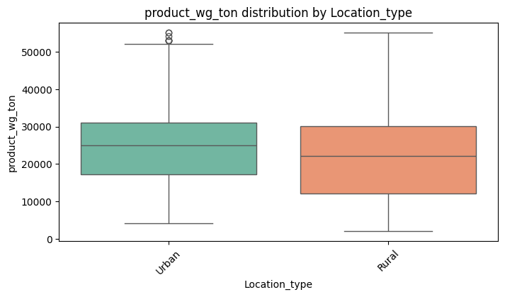

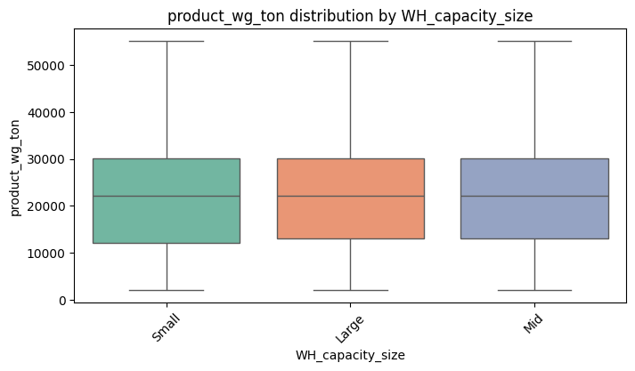

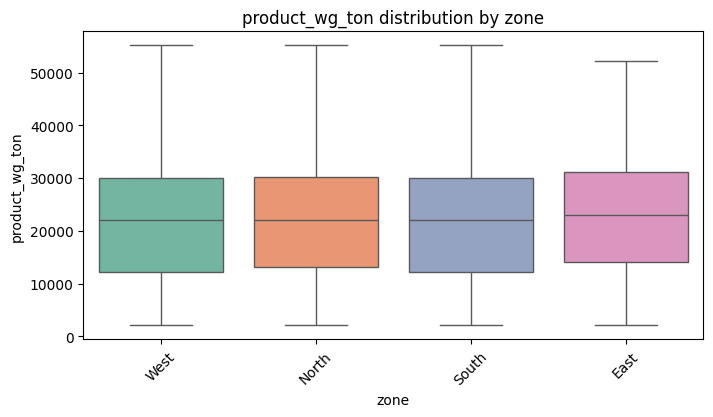

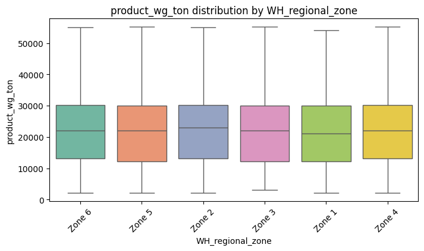

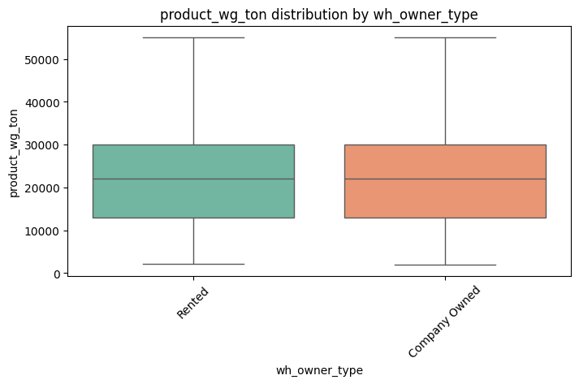

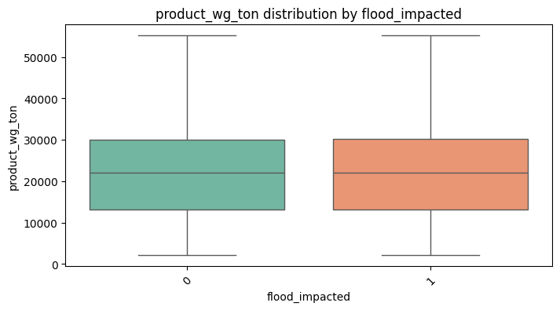

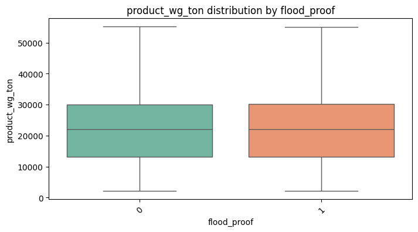

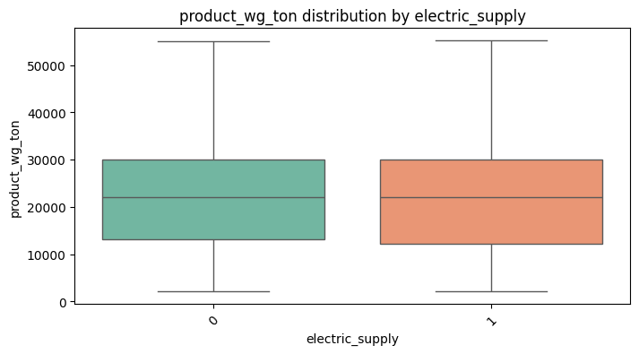

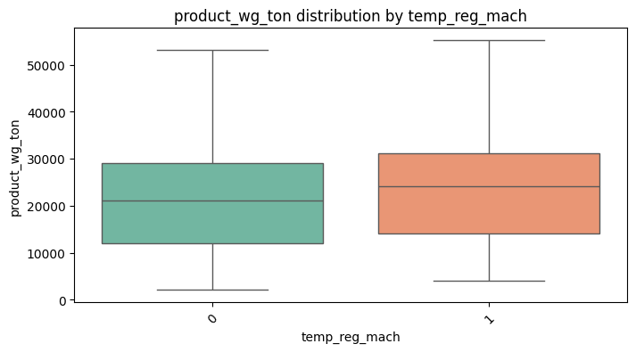

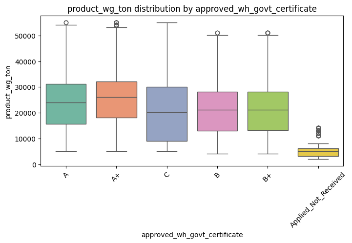

```python
def plot_categorical_vs_target(data, col, target='product_wg_ton'):
    plt.figure(figsize=(8,4))
    ax = sns.boxplot(data=data, x=col, y=target, palette='Set2')
    plt.title(f"{target} distribution by {col}")
    plt.xticks(rotation=45)
    plt.show()

cat_col1 = [
    'Location_type','WH_capacity_size','zone','WH_regional_zone','wh_owner_type',
    'flood_impacted','flood_proof','electric_supply',
    'temp_reg_mach','approved_wh_govt_certificate'
]

for col in cat_col1:
    plot_categorical_vs_target(data, col)
```

```python
cat_col1 = [
    'WH_capacity_size','zone','wh_owner_type',
    'flood_impacted','flood_proof','electric_supply'
]
```

### ANOVA Test of Significance between categorical variables and Target variable:

```python
import pandas as pd
import statsmodels.api as sm
import statsmodels.formula.api as smf

# wh_owner_type vs product weight
model_wo = smf.ols('product_wg_ton ~ C(wh_owner_type)', data=data).fit()
anova_wo = sm.stats.anova_lm(model_wo, typ=2)
print("\nwh_owner_type ANOVA:\n", anova_wo)

# WH_regional_zone vs product weight
model_Zo = smf.ols('product_wg_ton ~ C(WH_regional_zone)', data=data).fit()
anova_Zo = sm.stats.anova_lm(model_Zo, typ=2)
print("\nWH_regional_zone ANOVA:\n", anova_Zo)

# WH_capacity_size vs product weight
model_Ws = smf.ols('product_wg_ton ~ C(WH_capacity_size)', data=data).fit()
anova_Ws = sm.stats.anova_lm(model_Ws, typ=2)
print("\nWH_capacity_size ANOVA:\n", anova_Ws)

# Flood proof vs product weight
model_fp = smf.ols('product_wg_ton ~ C(flood_proof)', data=data).fit()
anova_fp = sm.stats.anova_lm(model_fp, typ=2)
print("\nFlood Proof ANOVA:\n", anova_fp)

# Flood impacted vs product weight
model_fi = smf.ols('product_wg_ton ~ C(flood_impacted)', data=data).fit()
anova_fi = sm.stats.anova_lm(model_fi, typ=2)
print("\nFlood Impacted ANOVA:\n", anova_fi)

# Electricity supply vs product weight
model_es = smf.ols('product_wg_ton ~ C(electric_supply)', data=data).fit()
anova_es = sm.stats.anova_lm(model_es, typ=2)
print("\nElectric Supply ANOVA:\n", anova_es)
```

```
wh_owner_type ANOVA:
                         sum_sq       df        F    PR(>F)
C(wh_owner_type)  1.135892e+08      1.0  0.84302  0.358543
Residual          3.368251e+12  24998.0      NaN       NaN

WH_regional_zone ANOVA:
                            sum_sq       df         F    PR(>F)
C(WH_regional_zone)  7.713408e+08      5.0  1.144966  0.333954
Residual             3.367593e+12  24994.0       NaN       NaN

WH_capacity_size ANOVA:
                            sum_sq       df         F    PR(>F)
C(WH_capacity_size)  2.979142e+08      2.0  1.105525  0.331053
Residual             3.368067e+12  24997.0       NaN       NaN

Flood Proof ANOVA:
                       sum_sq       df         F    PR(>F)
C(flood_proof)  6.564515e+05      1.0  0.004872  0.944355
Residual        3.368364e+12  24998.0       NaN       NaN

Flood Impacted ANOVA:
                          sum_sq       df         F    PR(>F)
C(flood_impacted)  1.780221e+07      1.0  0.132118  0.716249
Residual           3.368347e+12  24998.0       NaN       NaN

Electric Supply ANOVA:
                           sum_sq       df         F    PR(>F)
C(electric_supply)  1.571268e+07      1.0  0.116611  0.732743
Residual            3.368349e+12  24998.0       NaN       NaN
```

- These categorical variables do not impact product weight in the dataset.
- Including them in the predictive model would add noise rather than useful signal and hence it is safe to drop them from modeling.

```python
# Dropping the ANOVA Variables
data = data.drop(cat_col1, axis=1)
```

### **Univariate and Bivariate analysis for Numeric Variables**

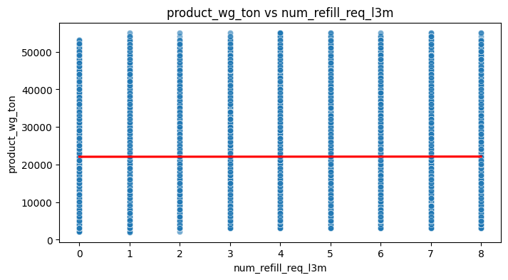

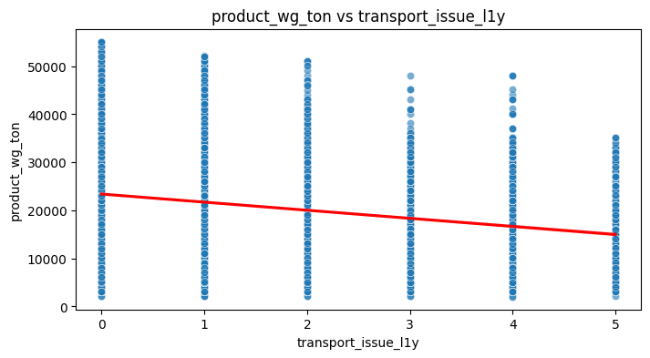

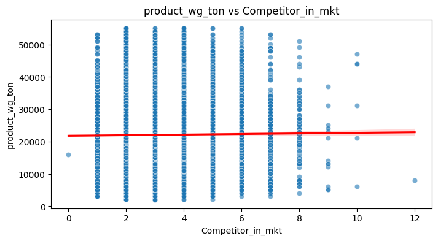

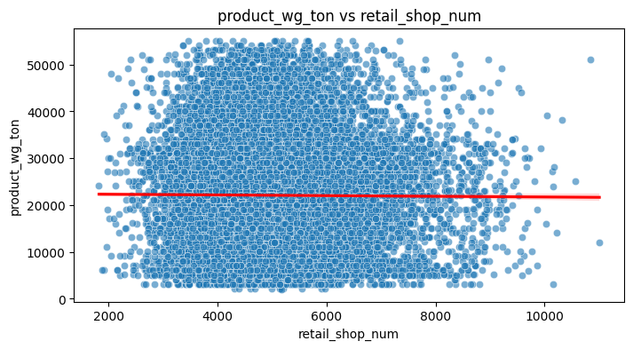

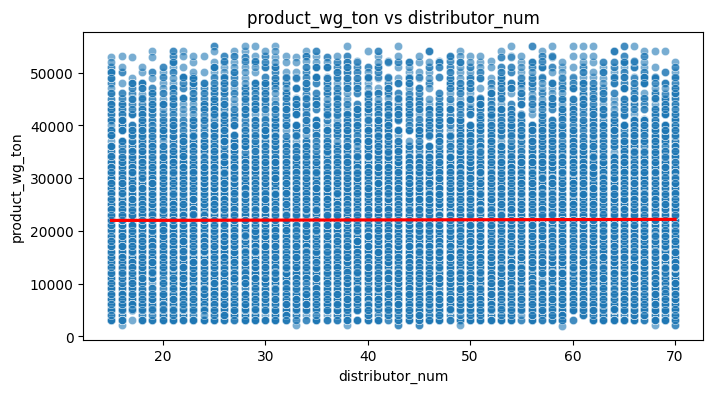

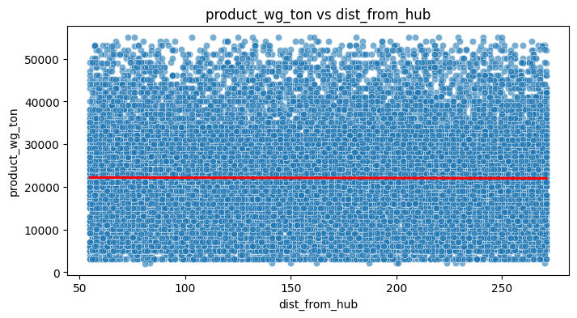

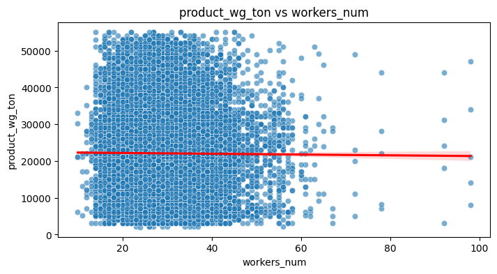

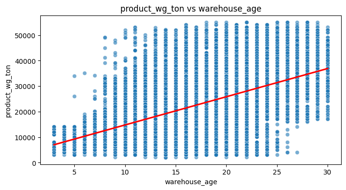

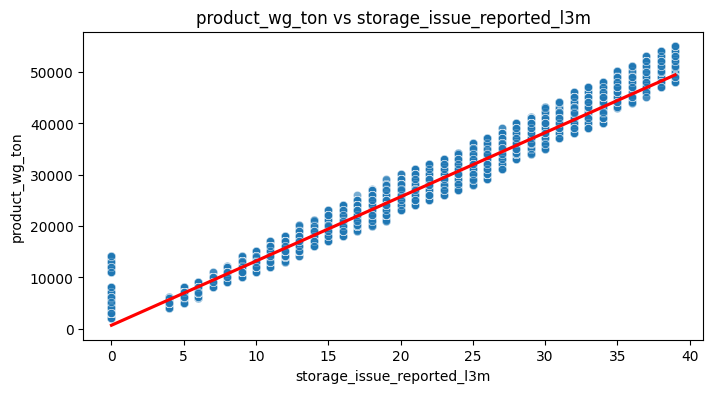

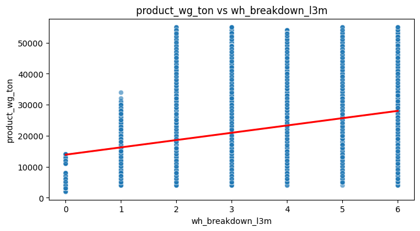

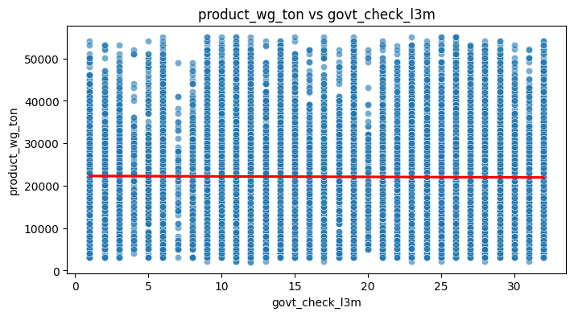

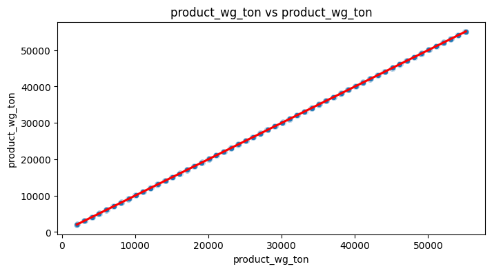

```python
def plot_numerical_vs_target(data, col, target='product_wg_ton'):
    plt.figure(figsize=(8,4))
    ax = sns.scatterplot(data=data, x=col, y=target, alpha=0.6)
    sns.regplot(data=data, x=col, y=target, scatter=False, color='red')  # regression line
    plt.title(f"{target} vs {col}")
    plt.show()

numerical_cols = [
    'num_refill_req_l3m','transport_issue_l1y',
    'Competitor_in_mkt','retail_shop_num','distributor_num',
    'dist_from_hub','workers_num','warehouse_age',
    'storage_issue_reported_l3m','wh_breakdown_l3m',
    'govt_check_l3m','product_wg_ton'
]

for col in numerical_cols:
    plot_numerical_vs_target(data, col)
```

```python
# Dropping the Num variables show no relationship with product weight as the graphs doesnot show any linear trend
num_var_drop = [
    'num_refill_req_l3m', 'Competitor_in_mkt',
    'retail_shop_num','distributor_num', 'dist_from_hub',
    'workers_num', 'govt_check_l3m'
]

data = data.drop(num_var_drop, axis=1)
```

### **Outlier treatment:**

- Outliers are seen in Location_type and approved_wh_govt_certificate variables.
- They can be treated through IQR method or log transformation method.
- However these are the real data that cannot be treated as they significantly impact the model. Hence we let them be and dont treat them.

### **Encoding Categorical Variables by Onehot encoding**

- Each category in a categorical feature is transformed into a new binary column.
- The column takes the value 1 if the observation belongs to that category, otherwise 0.
- This avoids assigning arbitrary numeric values (like 1, 2, 3) that could mislead models into thinking categories have an order.

```python
# Encoding
data = pd.get_dummies(data, drop_first=True)

data.info()
```

```
<class 'pandas.core.frame.DataFrame'>
RangeIndex: 25000 entries, 0 to 24999
Data columns (total 17 columns):
 #   Column                                             Non-Null Count  Dtype
---  ------                                             --------------  -----
 0   transport_issue_l1y                                25000 non-null  int64
 1   storage_issue_reported_l3m                         25000 non-null  int64
 2   temp_reg_mach                                      25000 non-null  int64
 3   wh_breakdown_l3m                                   25000 non-null  int64
 4   product_wg_ton                                     25000 non-null  int64
 5   warehouse_age                                      25000 non-null  int64
 6   Location_type_Urban                                25000 non-null  bool
 7   WH_regional_zone_Zone 2                            25000 non-null  bool
 8   WH_regional_zone_Zone 3                            25000 non-null  bool
 9   WH_regional_zone_Zone 4                            25000 non-null  bool
 10  WH_regional_zone_Zone 5                            25000 non-null  bool
 11  WH_regional_zone_Zone 6                            25000 non-null  bool
 12  approved_wh_govt_certificate_A+                    25000 non-null  bool
 13  approved_wh_govt_certificate_Applied_Not_Received  25000 non-null  bool
 14  approved_wh_govt_certificate_B                     25000 non-null  bool
 15  approved_wh_govt_certificate_B+                    25000 non-null  bool
 16  approved_wh_govt_certificate_C                     25000 non-null  bool
dtypes: bool(11), int64(6)
memory usage: 1.4 MB
```

- All categorical variables were one-hot encoded during preprocessing using pd.get_dummies. Since the dataset contains only numeric and boolean features afterward, no further encoding or label transformation is required before modeling.

## **Multivariate Analysis**

Multivariate analysis helps us understand the relationships between multiple variables simultaneously. We can analyse that with a heat map and a pair plot.

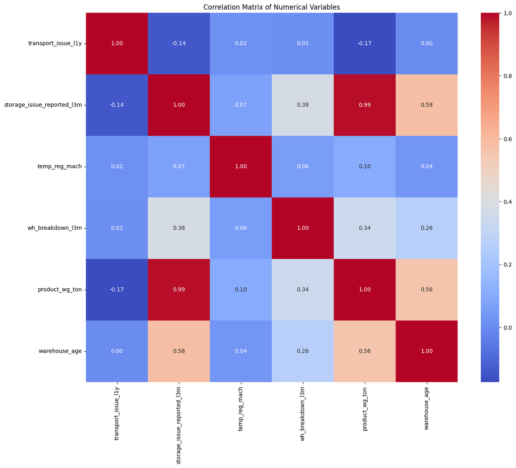

```python
# Step 1: Select numeric columns automatically
numeric_cols = data.select_dtypes(include=['int64', 'float64']).columns

plt.figure(figsize=(15, 12))
sns.heatmap(data[numeric_cols].corr(), annot=True, cmap='coolwarm', fmt='.2f')
plt.title('Correlation Matrix of Numerical Variables')
plt.show()
```

**Note: This indicates that storage issues are likely because of more volumes. And older warehouses carry more volumes.**

# Model Building:

## Target Variable

**product_wg_ton** - Quantity shipped in last 3 months

## Modeling Goal

Predict optimal shipment quantity per warehouse given:

```python
data.describe().T
```

|  | count | mean | std | min | 25% | 50% | 75% | max |
| --- | --- | --- | --- | --- | --- | --- | --- | --- |
| transport_issue_l1y | 25000.0 | 0.77368 | 1.199449 | 0.0 | 0.0 | 0.0 | 1.0 | 5.0 |
| storage_issue_reported_l3m | 25000.0 | 17.13044 | 9.161108 | 0.0 | 10.0 | 18.0 | 24.0 | 39.0 |
| temp_reg_mach | 25000.0 | 0.30328 | 0.459684 | 0.0 | 0.0 | 0.0 | 1.0 | 1.0 |
| wh_breakdown_l3m | 25000.0 | 3.48204 | 1.690335 | 0.0 | 2.0 | 3.0 | 5.0 | 6.0 |
| product_wg_ton | 25000.0 | 22102.63292 | 11607.755077 | 2065.0 | 13059.0 | 22101.0 | 30103.0 | 55151.0 |
| warehouse_age | 25000.0 | 16.60984 | 5.916592 | 3.0 | 13.0 | 17.0 | 20.0 | 30.0 |

### Defining X and Y(Target)

```python
# Define numeric and categorical column lists
numeric_cols = ['transport_issue_l1y','storage_issue_reported_l3m',
                'temp_reg_mach','wh_breakdown_l3m',
                'warehouse_age']   # exclude target here

categorical_cols = ['Location_type_Urban',
                    'WH_regional_zone_Zone 2','WH_regional_zone_Zone 3',
                    'WH_regional_zone_Zone 4','WH_regional_zone_Zone 5',
                    'WH_regional_zone_Zone 6',
                    'approved_wh_govt_certificate_A+',
                    'approved_wh_govt_certificate_Applied_Not_Received',
                    'approved_wh_govt_certificate_B',
                    'approved_wh_govt_certificate_B+',
                    'approved_wh_govt_certificate_C']

# Combine predictors
X = data[numeric_cols + categorical_cols]

# Target
y = data['product_wg_ton']
```

### Train–Test Split

```python
# splitting the data in 70:30 ratio for train to test data
from sklearn.model_selection import train_test_split

X_train, X_test, y_train, y_test = train_test_split(X, y, test_size=0.3, random_state=1)
```

### Feature scaling

```python
from sklearn.preprocessing import StandardScaler

scaler = StandardScaler()

X_train_scaled = scaler.fit_transform(X_train)
X_test_scaled = scaler.transform(X_test)
```

```python
print("Number of rows in train data =", X_train.shape[0])
print("Number of rows in test data =", X_test.shape[0])
```

```
Number of rows in train data = 17500
Number of rows in test data = 7500
```

**We choose 5 models for model building to check the performance of data.**

1. Linear regression model
2. Decision tree model
3. Random forest model
4. Bagging model
5. XG Boost model

## 1. Baseline Model – Linear Regression

**Linear Regression was chosen as a baseline due to its simplicity, interpretability, and effectiveness as a reference point for more complex models**

### We are predicting the demand through a simple linear regression model initially

```python
import statsmodels.api as sm

# Step 1: Convert boolean columns to int (needed for statsmodels)
bool_cols = X_train.select_dtypes(include='bool').columns
X_train[bool_cols] = X_train[bool_cols].astype(int)
X_test[bool_cols] = X_test[bool_cols].astype(int)

# Step 2: Add constant (intercept)
X_train_sm = sm.add_constant(X_train)
X_test_sm = sm.add_constant(X_test)

# Step 3: Fit the model
olsmodel = sm.OLS(y_train, X_train_sm).fit()

# Step 4: Print model summary
print(olsmodel.summary())
```

```
                            OLS Regression Results
==============================================================================
Dep. Variable:         product_wg_ton   R-squared:                       0.990
Model:                            OLS   Adj. R-squared:                  0.990
Method:                 Least Squares   F-statistic:                 1.110e+05
Date:                Sun, 11 Jan 2026   Prob (F-statistic):               0.00
Time:                        13:24:55   Log-Likelihood:            -1.4816e+05
No. Observations:               17500   AIC:                         2.964e+05
Df Residuals:                   17483   BIC:                         2.965e+05
Df Model:                          16
Covariance Type:            nonrobust
=====================================================================================================================
                                                        coef    std err          t      P>|t|      [0.025      0.975]
---------------------------------------------------------------------------------------------------------------------
const                                              1209.5786     47.358     25.541      0.000    1116.751    1302.406
transport_issue_l1y                                -235.3254      7.401    -31.795      0.000    -249.833    -220.818
storage_issue_reported_l3m                         1297.3286      1.289   1006.565      0.000    1294.802    1299.855
temp_reg_mach                                       659.3888     21.249     31.031      0.000     617.738     701.039
wh_breakdown_l3m                                    -37.2992      5.851     -6.375      0.000     -48.767     -25.831
warehouse_age                                       -30.9220      1.831    -16.891      0.000     -34.510     -27.334
Location_type_Urban                                 -33.8423     31.974     -1.058      0.290     -96.515      28.831
WH_regional_zone_Zone 2                             -28.3409     39.636     -0.715      0.475    -106.031      49.349
WH_regional_zone_Zone 3                             -67.3422     39.868     -1.689      0.091    -145.488      10.803
WH_regional_zone_Zone 4                             -16.9834     37.247     -0.456      0.648     -89.992      56.025
WH_regional_zone_Zone 5                             -45.9851     36.685     -1.254      0.210    -117.892      25.921
WH_regional_zone_Zone 6                             -17.9048     34.048     -0.526      0.599     -84.642      48.833
approved_wh_govt_certificate_A+                     114.7716     31.579      3.634      0.000      52.874     176.669
approved_wh_govt_certificate_Applied_Not_Received  4791.5347     55.905     85.709      0.000    4681.956    4901.113
approved_wh_govt_certificate_B                    -2041.2839     28.088    -72.674      0.000   -2096.340   -1986.228
approved_wh_govt_certificate_B+                   -2077.1073     28.100    -73.918      0.000   -2132.186   -2022.028
approved_wh_govt_certificate_C                     -265.0184     27.519     -9.630      0.000    -318.959    -211.078
==============================================================================
Omnibus:                     3757.038   Durbin-Watson:                   2.009
Prob(Omnibus):                  0.000   Jarque-Bera (JB):            17708.670
Skew:                           0.970   Prob(JB):                         0.00
Kurtosis:                       7.530   Cond. No.                         239.
==============================================================================

Notes:
[1] Standard Errors assume that the covariance matrix of the errors is correctly specified.
```

### Calculating both Train and Test MAE and RMSE

- This gives us a complete picture of model fit and generalization.

```python
from sklearn.metrics import mean_absolute_error, mean_squared_error, r2_score
import numpy as np

# Predictions
y_train_pred = olsmodel.predict(X_train_sm)
y_test_pred  = olsmodel.predict(X_test_sm)

# Train MAE, RMSE, MAPE, R2
mae_train = mean_absolute_error(y_train, y_train_pred)
rmse_train = np.sqrt(mean_squared_error(y_train, y_train_pred))
mape_train = np.mean(np.abs((y_train - y_train_pred) / y_train)) * 100
r2_train = r2_score(y_train, y_train_pred)

# Adjusted R² for train
n_train = X_train_sm.shape[0]   # number of observations
p = X_train_sm.shape[1]         # number of predictors
adj_r2_train = 1 - (1 - r2_train) * (n_train - 1) / (n_train - p - 1)

# Test MAE, RMSE, MAPE, R2
mae_test = mean_absolute_error(y_test, y_test_pred)
rmse_test = np.sqrt(mean_squared_error(y_test, y_test_pred))
mape_test = np.mean(np.abs((y_test - y_test_pred) / y_test)) * 100
r2_test = r2_score(y_test, y_test_pred)

# Adjusted R² for test
n_test = X_test_sm.shape[0]
adj_r2_test = 1 - (1 - r2_test) * (n_test - 1) / (n_test - p - 1)

# Print results
print("Linear regression Train MAE:", mae_train)
print("Linear regression Train RMSE:", rmse_train)
print("Linear regression Train MAPE (%):", mape_train)
print("Linear regression Train R²:", r2_train)
print("Linear regression Train Adjusted R²:", adj_r2_train)

print("Linear regression Test MAE:", mae_test)
print("Linear regression Test RMSE:", rmse_test)
print("Linear regression Test MAPE (%):", mape_test)
print("Linear regression Test R²:", r2_test)
print("Linear regression Test Adjusted R²:", adj_r2_test)
```

```
Linear regression Train MAE: 882.7044063787175
Linear regression Train RMSE: 1149.7097885824628
Linear regression Train MAPE (%): 6.1552995640674
Linear regression Train R²: 0.9902521416313212
Linear regression Train Adjusted R²: 0.9902426625332622
Linear regression Test MAE: 874.6295192012799
Linear regression Test RMSE: 1112.5071956930524
Linear regression Test MAPE (%): 6.064516400448724
Linear regression Test R²: 0.9906734735222249
Linear regression Test Adjusted R²: 0.9906522825371779
```

- Train MAE = 883 tons / Test MAE = 875 tons - Very close, showing strong generalization.
- Train RMSE = 1150 tons / Test RMSE = 1113 tons - Slightly higher than MAE, as expected.
- Train MAPE = 6.16% / Test MAPE = 6.06% - Predictions are, on average, within ~6% of actual product weights. This is excellent accuracy for forecasting.
- R² (0.9903): The model explains ~99% of the variance in shipment quantities.
- Adjusted R² (0.99024): Almost identical to R², meaning the predictors are genuinely useful and not just increasing the score

**Note: MAPE was chosen as the primary metric because percentage error is more interpretable.**

**OLS achieved R square = 0.99, MAE = 875 tons, RMSE = 1113 tons, MAPE = 6% and R2 = 99%, Train and test errors are consistent, showing strong generalization.**

## 2. Building Decision Tree model

```python
from sklearn.metrics import mean_absolute_error, mean_squared_error, r2_score
import numpy as np

# Predictions
y_train_pred_dt = dt_model.predict(X_train)
y_test_pred_dt = dt_model.predict(X_test)

# Train metrics
mae_train_dt = mean_absolute_error(y_train, y_train_pred_dt)
rmse_train_dt = np.sqrt(mean_squared_error(y_train, y_train_pred_dt))
mape_train_dt = np.mean(np.abs((y_train - y_train_pred_dt) / y_train)) * 100
r2_train_dt = r2_score(y_train, y_train_pred_dt)

# Adjusted R² for train
n_train = X_train.shape[0]   # number of observations
p = X_train.shape[1]         # number of predictors
adj_r2_train_dt = 1 - (1 - r2_train_dt) * (n_train - 1) / (n_train - p - 1)

# Test metrics
mae_test_dt = mean_absolute_error(y_test, y_test_pred_dt)
rmse_test_dt = np.sqrt(mean_squared_error(y_test, y_test_pred_dt))
mape_test_dt = np.mean(np.abs((y_test - y_test_pred_dt) / y_test)) * 100
r2_test_dt = r2_score(y_test, y_test_pred_dt)

# Adjusted R² for test
n_test = X_test.shape[0]
adj_r2_test_dt = 1 - (1 - r2_test_dt) * (n_test - 1) / (n_test - p - 1)

# Print results
print("Decision Tree Train MAE:", mae_train_dt)
print("Decision Tree Train RMSE:", rmse_train_dt)
print("Decision Tree Train MAPE (%):", mape_train_dt)
print("Decision Tree Train R²:", r2_train_dt)
print("Decision Tree Train Adjusted R²:", adj_r2_train_dt)

print("Decision Tree Test MAE:", mae_test_dt)
print("Decision Tree Test RMSE:", rmse_test_dt)
print("Decision Tree Test MAPE (%):", mape_test_dt)
print("Decision Tree Test R²:", r2_test_dt)
print("Decision Tree Test Adjusted R²:", adj_r2_test_dt)
```

```
Decision Tree Train MAE: 74.00909430373919
Decision Tree Train RMSE: 407.74283438860886
Decision Tree Train MAPE (%): 0.8473174393108147
Decision Tree Train R²: 0.9987739577746385
Decision Tree Train Adjusted R²: 0.9987728357317622
Decision Tree Test MAE: 792.5922235357496
Decision Tree Test RMSE: 1158.43281732236
Decision Tree Test MAPE (%): 4.734361283715063
Decision Tree Test R²: 0.9898875596111664
Decision Tree Test Adjusted R²: 0.9898659373946461
```

- MAE(74.0): On average, predictions are off by only ~74 tons in training — extremely low error.
- RMSE (407.7): Errors are small, confirming the model fits training data very tightly.
- MAPE (0.85%): Less than 1% deviation from actual values — near-perfect fit.
- R² (0.9988) & Adjusted R² (0.99877): The model explains almost all variance in training data.

**This is a sign of overfitting: the model memorized training data almost perfectly**

## 3. Building Random forest model

```python
from sklearn.ensemble import RandomForestRegressor
from sklearn.metrics import mean_absolute_error, mean_squared_error, r2_score
import numpy as np

# Initialize Random Forest model
rf_model = RandomForestRegressor(
    n_estimators=100,       # number of trees
    random_state=42,        # reproducibility
    max_depth=None,         # let trees grow fully (can tune later)
    n_jobs=-1               # use all cores for speed
)

# Fit the model
rf_model.fit(X_train, y_train)

# Predictions
y_train_pred_rf = rf_model.predict(X_train)
y_test_pred_rf = rf_model.predict(X_test)

# Train metrics
mae_train_rf = mean_absolute_error(y_train, y_train_pred_rf)
rmse_train_rf = np.sqrt(mean_squared_error(y_train, y_train_pred_rf))
mape_train_rf = np.mean(np.abs((y_train - y_train_pred_rf) / y_train)) * 100
r2_train_rf = r2_score(y_train, y_train_pred_rf)

# Adjusted R² for train
n_train = X_train.shape[0]   # number of observations
p = X_train.shape[1]         # number of predictors
adj_r2_train_rf = 1 - (1 - r2_train_rf) * (n_train - 1) / (n_train - p - 1)

# Test metrics
mae_test_rf = mean_absolute_error(y_test, y_test_pred_rf)
rmse_test_rf = np.sqrt(mean_squared_error(y_test, y_test_pred_rf))
mape_test_rf = np.mean(np.abs((y_test - y_test_pred_rf) / y_test)) * 100
r2_test_rf = r2_score(y_test, y_test_pred_rf)

# Adjusted R² for test
n_test = X_test.shape[0]
adj_r2_test_rf = 1 - (1 - r2_test_rf) * (n_test - 1) / (n_test - p - 1)

# Print results
print("Random Forest Train MAE:", mae_train_rf)
print("Random Forest Train RMSE:", rmse_train_rf)
print("Random Forest Train MAPE (%):", mape_train_rf)
print("Random Forest Train R²:", r2_train_rf)
print("Random Forest Train Adjusted R²:", adj_r2_train_rf)

print("Random Forest Test MAE:", mae_test_rf)
print("Random Forest Test RMSE:", rmse_test_rf)
print("Random Forest Test MAPE (%):", mape_test_rf)
print("Random Forest Test R²:", r2_test_rf)
print("Random Forest Test Adjusted R²:", adj_r2_test_rf)
```

```
Random Forest Train MAE: 297.38351819227336
Random Forest Train RMSE: 513.0437368009373
Random Forest Train MAPE (%): 2.0600477820817567
Random Forest Train R²: 0.9980589285007697
Random Forest Train Adjusted R²: 0.9980571520811627
Random Forest Test MAE: 677.1176143262364
Random Forest Test RMSE: 918.4714715282316
Random Forest Test MAPE (%): 4.153889133331057
Random Forest Test R²: 0.9936430965871589
Random Forest Test Adjusted R²: 0.9936295043842182
```

- Train MAE ≈ 297 tons / Train MAPE ≈ 2.06% → Very low training error, showing the forest fits training data strongly.
- Test MAE ≈ 677 tons / Test MAPE ≈ 4.15% → Test error is higher than train but still better than OLS (MAPE ≈ 6%) and Decision Tree (MAPE ≈ 4.73%).
- RMSE gap (Train ≈ 513 vs Test ≈ 918)
- R2 for both test and train data explains nearly 99% of variance. → Some overfitting, but much less severe than the single Decision Tree
- “Random Forest improved generalization compared to a single Decision Tree. Test MAPE dropped to 4.15%, outperforming the OLS baseline (~6%). The train–test gap is moderate, suggesting the ensemble stabilizes predictions while reducing overfitting.

## 4. Building Bagging model

```python
from sklearn.ensemble import BaggingRegressor
from sklearn.tree import DecisionTreeRegressor
from sklearn.metrics import mean_absolute_error, mean_squared_error, r2_score
import numpy as np

# Initialize Bagging model with Decision Trees as base learners
bagging_model = BaggingRegressor(
    estimator=DecisionTreeRegressor(),
    n_estimators=100,
    random_state=42,
    n_jobs=-1
)

# Fit the model
bagging_model.fit(X_train, y_train)

# Predictions
y_train_pred_bag = bagging_model.predict(X_train)
y_test_pred_bag = bagging_model.predict(X_test)

# Train metrics
mae_train_bag = mean_absolute_error(y_train, y_train_pred_bag)
rmse_train_bag = np.sqrt(mean_squared_error(y_train, y_train_pred_bag))
mape_train_bag = np.mean(np.abs((y_train - y_train_pred_bag) / y_train)) * 100
r2_train_bag = r2_score(y_train, y_train_pred_bag)

# Adjusted R² for train
n_train = X_train.shape[0]   # number of observations
p = X_train.shape[1]         # number of predictors
adj_r2_train_bag = 1 - (1 - r2_train_bag) * (n_train - 1) / (n_train - p - 1)

# Test metrics
mae_test_bag = mean_absolute_error(y_test, y_test_pred_bag)
rmse_test_bag = np.sqrt(mean_squared_error(y_test, y_test_pred_bag))
mape_test_bag = np.mean(np.abs((y_test - y_test_pred_bag) / y_test)) * 100
r2_test_bag = r2_score(y_test, y_test_pred_bag)

# Adjusted R² for test
n_test = X_test.shape[0]
adj_r2_test_bag = 1 - (1 - r2_test_bag) * (n_test - 1) / (n_test - p - 1)

# Print results
print("Bagging Train MAE:", mae_train_bag)
print("Bagging Train RMSE:", rmse_train_bag)
print("Bagging Train MAPE (%):", mape_train_bag)
print("Bagging Train R²:", r2_train_bag)
print("Bagging Train Adjusted R²:", adj_r2_train_bag)

print("Bagging Test MAE:", mae_test_bag)
print("Bagging Test RMSE:", rmse_test_bag)
print("Bagging Test MAPE (%):", mape_test_bag)
print("Bagging Test R²:", r2_test_bag)
print("Bagging Test Adjusted R²:", adj_r2_test_bag)
```

```
Bagging Train MAE: 297.5265703794719
Bagging Train RMSE: 513.078910421441
Bagging Train MAPE (%): 2.060314938183841
Bagging Train R²: 0.9980586623369018
Bagging Train Adjusted R²: 0.9980568856737084
Bagging Test MAE: 677.0502954732042
Bagging Test RMSE: 918.3387195035842
Bagging Test MAPE (%): 4.155758348717517
Bagging Test R²: 0.9936449340548178
Bagging Test Adjusted R²: 0.9936313457807134
```

- MAE: Training error is very low (~ 298 tons), while test error rises (~ 677 tons), showing some generalization gap but still acceptable.
- RMSE: Training deviations are small (~ 513), test deviations larger (~918), indicating higher variance on unseen data.
- MAPE: Training predictions deviate by ~2%, test predictions by ~4%, reflecting strong but slightly reduced accuracy on new data.
- R²: Training fit is near perfect (0.998), test fit remains excellent (0.994), confirming the model explains almost all variance.
- Adjusted R²: Training adjusted R² (0.99806) and test adjusted R² (0.99363) closely mirror R², validating that predictors are genuinely useful without overinflation

**Bagging strikes a balance: it captures nonlinear relationships better than Linear Regression, avoids the extreme overfitting of a single Decision Tree, and performs comparably to Random Forest.**

## 5. Building XG Boost model

```python
from xgboost import XGBRegressor
from sklearn.metrics import mean_absolute_error, mean_squared_error, r2_score
import numpy as np

# Initialize XGBoost model
xgb_model = XGBRegressor(
    n_estimators=200,
    learning_rate=0.1,
    max_depth=6,
    subsample=0.8,
    colsample_bytree=0.8,
    random_state=42,
    n_jobs=-1
)

# Fit the model
xgb_model.fit(X_train, y_train)

# Predictions
y_train_pred_xgb = xgb_model.predict(X_train)
y_test_pred_xgb = xgb_model.predict(X_test)

# Train metrics
mae_train_xgb = mean_absolute_error(y_train, y_train_pred_xgb)
rmse_train_xgb = np.sqrt(mean_squared_error(y_train, y_train_pred_xgb))
mape_train_xgb = np.mean(np.abs((y_train - y_train_pred_xgb) / y_train)) * 100
r2_train_xgb = r2_score(y_train, y_train_pred_xgb)

# Adjusted R² for train
n_train = X_train.shape[0]   # number of observations
p = X_train.shape[1]         # number of predictors
adj_r2_train_xgb = 1 - (1 - r2_train_xgb) * (n_train - 1) / (n_train - p - 1)

# Test metrics
mae_test_xgb = mean_absolute_error(y_test, y_test_pred_xgb)
rmse_test_xgb = np.sqrt(mean_squared_error(y_test, y_test_pred_xgb))
mape_test_xgb = np.mean(np.abs((y_test - y_test_pred_xgb) / y_test)) * 100
r2_test_xgb = r2_score(y_test, y_test_pred_xgb)

# Adjusted R² for test
n_test = X_test.shape[0]
adj_r2_test_xgb = 1 - (1 - r2_test_xgb) * (n_test - 1) / (n_test - p - 1)

# Print results
print("XGBoost Train MAE:", mae_train_xgb)
print("XGBoost Train RMSE:", rmse_train_xgb)
print("XGBoost Train MAPE (%):", mape_train_xgb)
print("XGBoost Train R²:", r2_train_xgb)
print("XGBoost Train Adjusted R²:", adj_r2_train_xgb)

print("XGBoost Test MAE:", mae_test_xgb)
print("XGBoost Test RMSE:", rmse_test_xgb)
print("XGBoost Test MAPE (%):", mape_test_xgb)
print("XGBoost Test R²:", r2_test_xgb)
print("XGBoost Test Adjusted R²:", adj_r2_test_xgb)
```

```
XGBoost Train MAE: 603.8773193359375
XGBoost Train RMSE: 820.3350687371594
XGBoost Train MAPE (%): 3.764584749922916
XGBoost Train R²: 0.995037317276001
XGBoost Train Adjusted R²: 0.9950327755541235
XGBoost Test MAE: 649.2354125976562
XGBoost Test RMSE: 857.7701833824722
XGBoost Test MAPE (%): 4.0172791587631105
XGBoost Test R²: 0.9944555759429932
XGBoost Test Adjusted R²: 0.9944437209670595
```

- MAE: Training error is ~604 tons, test error ~649 tons, showing consistently low average prediction error.
- RMSE: Training deviations are ~820, test deviations ~858, indicating stable variance across seen and unseen data.
- MAPE: Training predictions deviate by ~3.8%, test predictions by ~4.0%, reflecting strong accuracy with minimal drift.
- R²: Training fit is 0.995, test fit 0.994, confirming the model explains nearly all variance in shipment quantities.
- Adjusted R²: Training adjusted R² (0.99503) and test adjusted R² (0.99444) closely mirror R², validating predictor usefulness without inflation
- **Very small gap, showing excellent balance between bias and variance. “XGBoost achieved the lowest test error among all models so far, with MAPE ≈ 4%. This indicates strong predictive accuracy and stability, outperforming both OLS and Random Forest. The small train–test gap suggests the model generalizes well without severe overfitting.**

## **Comparing all the models to check the best performance**

```python
import pandas as pd

# Step 1: Assemble all model metrics
model_metrics = {
    "Linear Regression": {
        "Train MAE": mae_train,
        "Test MAE": mae_test,
        "Train RMSE": rmse_train,
        "Test RMSE": rmse_test,
        "Train MAPE": mape_train,
        "Test MAPE": mape_test,
        "Train R²": r2_train,
        "Test R²": r2_test,
        "Train Adj R²": adj_r2_train,
        "Test Adj R²": adj_r2_test
    },
    "Decision Tree": {
        "Train MAE": mae_train_dt,
        "Test MAE": mae_test_dt,
        "Train RMSE": rmse_train_dt,
        "Test RMSE": rmse_test_dt,
        "Train MAPE": mape_train_dt,
        "Test MAPE": mape_test_dt,
        "Train R²": r2_train_dt,
        "Test R²": r2_test_dt,
        "Train Adj R²": adj_r2_train_dt,
        "Test Adj R²": adj_r2_test_dt
    },
    "Random Forest": {
        "Train MAE": mae_train_rf,
        "Test MAE": mae_test_rf,
        "Train RMSE": rmse_train_rf,
        "Test RMSE": rmse_test_rf,
        "Train MAPE": mape_train_rf,
        "Test MAPE": mape_test_rf,
        "Train R²": r2_train_rf,
        "Test R²": r2_test_rf,
        "Train Adj R²": adj_r2_train_rf,
        "Test Adj R²": adj_r2_test_rf
    },
    "Bagging": {
        "Train MAE": mae_train_bag,
        "Test MAE": mae_test_bag,
        "Train RMSE": rmse_train_bag,
        "Test RMSE": rmse_test_bag,
        "Train MAPE": mape_train_bag,
        "Test MAPE": mape_test_bag,
        "Train R²": r2_train_bag,
        "Test R²": r2_test_bag,
        "Train Adj R²": adj_r2_train_bag,
        "Test Adj R²": adj_r2_test_bag
    },
    "XGBoost": {
        "Train MAE": mae_train_xgb,
        "Test MAE": mae_test_xgb,
        "Train RMSE": rmse_train_xgb,
        "Test RMSE": rmse_test_xgb,
        "Train MAPE": mape_train_xgb,
        "Test MAPE": mape_test_xgb,
        "Train R²": r2_train_xgb,
        "Test R²": r2_test_xgb,
        "Train Adj R²": adj_r2_train_xgb,
        "Test Adj R²": adj_r2_test_xgb
    }
}

# Step 2: Convert to DataFrame
metrics_df = pd.DataFrame(model_metrics).T

# Step 3: Print the summary table
print(metrics_df)
```

```
                    Train MAE    Test MAE   Train RMSE    Test RMSE  \
Linear Regression  882.704406  874.629519  1149.709789  1112.507196
Decision Tree       74.009094  792.592224   407.742834  1158.432817
Random Forest      297.383518  677.117614   513.043737   918.471472
Bagging            297.526570  677.050295   513.078910   918.338720
XGBoost            603.877319  649.235413   820.335069   857.770183

                   Train MAPE  Test MAPE  Train R²   Test R²  Train Adj R²  \
Linear Regression    6.155300   6.064516  0.990252  0.990673      0.990243
Decision Tree        0.847317   4.734361  0.998774  0.989888      0.998773
Random Forest        2.060048   4.153889  0.998059  0.993643      0.998057
Bagging              2.060315   4.155758  0.998059  0.993645      0.998057
XGBoost              3.764585   4.017279  0.995037  0.994456      0.995033

                   Test Adj R²
Linear Regression     0.990652
Decision Tree         0.989866
Random Forest         0.993630
Bagging               0.993631
XGBoost               0.994444
```

- Overall when compared with all models **XGBoost** consistently ranks best across MAE, RMSE, MAPE, R², and Adjusted R² on test data.
- It balances flexibility and generalization better than other models.
- However we would like to hypertune three best models and observe the results.
- The best three models are **XGBOOST, Random forest, Bagging.**

## **Hyperparameter tuning**

Typical Hyperparameters to Tune in the models - **XGBOOST, Random forest, Bagging.**

- max_depth (limit tree depth)
- min_samples_split, min_samples_leaf (control branching)
- n_estimators (number of trees)
- One can use GridSearchCV or RandomizedSearchCV from scikit-learn

# Hyperparameter tuning for Random forest model

```python
from sklearn.ensemble import RandomForestRegressor
from sklearn.model_selection import GridSearchCV

# Define parameter grid
param_grid = {
    'n_estimators': [100, 200, 300],
    'max_depth': [None, 10, 20],
    'min_samples_split': [2, 5],
    'min_samples_leaf': [1, 2],
    'max_features': ['sqrt'] # Changed 'auto' to 'sqrt'
}

# Initialize model
rf_model = RandomForestRegressor(random_state=42, n_jobs=-1)

# Grid search
grid_search_rf = GridSearchCV(
    estimator=rf_model,
    param_grid=param_grid,
    cv=3,
    scoring='neg_mean_absolute_error',
    n_jobs=-1
)

grid_search_rf.fit(X_train, y_train)

print("Best parameters:", grid_search_rf.best_params_)
print("Best score:", -grid_search_rf.best_score_)
```

```
Best parameters: {'max_depth': None, 'max_features': 'sqrt', 'min_samples_leaf': 1, 'min_samples_split': 2, 'n_estimators': 200}
Best score: 913.4734803446709
```

# Hyperparameter tuning for Bagging model

```python
from sklearn.ensemble import BaggingRegressor
from sklearn.tree import DecisionTreeRegressor
from sklearn.model_selection import GridSearchCV

# Define parameter grid
param_grid = {
    'n_estimators': [50, 100, 200],
    'max_samples': [0.5, 0.7, 1.0],
    'max_features': [0.5, 0.7, 1.0],
    'bootstrap': [True, False]
}

# Initialize model (using DecisionTreeRegressor as base estimator)
bag_model = BaggingRegressor(
    estimator=DecisionTreeRegressor(random_state=42),
    random_state=42,
    n_jobs=-1
)

# Grid search
grid_search_bag = GridSearchCV(
    estimator=bag_model,
    param_grid=param_grid,
    cv=3,
    scoring='neg_mean_absolute_error',
    n_jobs=-1
)

grid_search_bag.fit(X_train, y_train)

print("Best parameters:", grid_search_bag.best_params_)
print("Best score:", -grid_search_bag.best_score_)
```

```
Best parameters: {'bootstrap': True, 'max_features': 1.0, 'max_samples': 0.5, 'n_estimators': 200}
Best score: 693.4899139466751
```

# Hyperparameter tuning for XGB model

```python
from xgboost import XGBRegressor
from sklearn.model_selection import GridSearchCV

# Define parameter grid
param_grid = {
    'n_estimators': [100, 200, 300],
    'learning_rate': [0.05, 0.1, 0.2],
    'max_depth': [3, 6, 10],
    'subsample': [0.8, 1.0],
    'colsample_bytree': [0.8, 1.0]
}

# Initialize model
xgb_model = XGBRegressor(random_state=42, n_jobs=-1)

# Grid search
grid_search_xgb = GridSearchCV(
    estimator=xgb_model,
    param_grid=param_grid,
    cv=3,
    scoring='neg_mean_absolute_error',
    n_jobs=-1
)

grid_search_xgb.fit(X_train, y_train)

print("Best parameters:", grid_search_xgb.best_params_)
print("Best score:", -grid_search_xgb.best_score_)
```

```
Best parameters: {'colsample_bytree': 1.0, 'learning_rate': 0.05, 'max_depth': 6, 'n_estimators': 200, 'subsample': 0.8}
Best score: 659.9071044921875
```

```python
# Collect best results from each hypertuned model
results = {
    "XGBoost": {
        "Best Params": grid_search_xgb.best_params_,
        "Best Score (MAE)": -grid_search_xgb.best_score_
    },
    "Random Forest": {
        "Best Params": grid_search_rf.best_params_,
        "Best Score (MAE)": -grid_search_rf.best_score_
    },
    "Bagging": {
        "Best Params": grid_search_bag.best_params_,
        "Best Score (MAE)": -grid_search_bag.best_score_
    }
}

# Convert to DataFrame for clean comparison
results_df = pd.DataFrame(results).T

print(results_df)
```

```
                                                     Best Params  \
XGBoost        {'colsample_bytree': 1.0, 'learning_rate': 0.0...
Random Forest  {'max_depth': None, 'max_features': 'sqrt', 'm...
Bagging        {'bootstrap': True, 'max_features': 1.0, 'max_...

              Best Score (MAE)
XGBoost             659.907104
Random Forest        913.47348
Bagging             693.489914
```

- XGBoost remains the best performer after tuning, with the lowest MAE (~660).
- Bagging comes second (~693), very close to XGBoost.
- Random Forest lags behind (~913), showing higher error even after tuning.

**Best Model: XGBoost** It consistently delivers the lowest error and strongest generalization, making it the prime candidate for deployment or further fine‑tuning

## **Retraining tuned XG boost on full training set**

```python
from xgboost import XGBRegressor
from sklearn.metrics import mean_absolute_error, mean_squared_error, r2_score
import numpy as np

# Retrain tuned XGBoost with best parameters
xgb_tuned = XGBRegressor(
    colsample_bytree=1.0,
    learning_rate=0.05,
    max_depth=6,
    n_estimators=200,
    subsample=0.8,
    random_state=42,
    n_jobs=-1
)

# Fit on full training set
xgb_tuned.fit(X_train, y_train)

# Predictions
y_train_pred_xgb_tuned = xgb_tuned.predict(X_train)
y_test_pred_xgb_tuned = xgb_tuned.predict(X_test)

# Helper function for Adjusted R²
def adjusted_r2(r2, n, p):
    return 1 - (1 - r2) * (n - 1) / (n - p - 1)

# Train metrics
mae_train_xgb_tuned = mean_absolute_error(y_train, y_train_pred_xgb_tuned)
rmse_train_xgb_tuned = np.sqrt(mean_squared_error(y_train, y_train_pred_xgb_tuned))
mape_train_xgb_tuned = np.mean(np.abs((y_train - y_train_pred_xgb_tuned) / y_train)) * 100
r2_train_xgb_tuned = r2_score(y_train, y_train_pred_xgb_tuned)
adj_r2_train_xgb_tuned = adjusted_r2(r2_train_xgb_tuned, X_train.shape[0], X_train.shape[1])

# Test metrics
mae_test_xgb_tuned = mean_absolute_error(y_test, y_test_pred_xgb_tuned)
rmse_test_xgb_tuned = np.sqrt(mean_squared_error(y_test, y_test_pred_xgb_tuned))
mape_test_xgb_tuned = np.mean(np.abs((y_test - y_test_pred_xgb_tuned) / y_test)) * 100
r2_test_xgb_tuned = r2_score(y_test, y_test_pred_xgb_tuned)
adj_r2_test_xgb_tuned = adjusted_r2(r2_test_xgb_tuned, X_test.shape[0], X_test.shape[1])

# Print results
print("Tuned XGBoost Train MAE:", mae_train_xgb_tuned)
print("Tuned XGBoost Train RMSE:", rmse_train_xgb_tuned)
print("Tuned XGBoost Train MAPE (%):", mape_train_xgb_tuned)
print("Tuned XGBoost Train R²:", r2_train_xgb_tuned)
print("Tuned XGBoost Train Adjusted R²:", adj_r2_train_xgb_tuned)

print("Tuned XGBoost Test MAE:", mae_test_xgb_tuned)
print("Tuned XGBoost Test RMSE:", rmse_test_xgb_tuned)
print("Tuned XGBoost Test MAPE (%):", mape_test_xgb_tuned)
print("Tuned XGBoost Test R²:", r2_test_xgb_tuned)
print("Tuned XGBoost Test Adjusted R²:", adj_r2_test_xgb_tuned)
```

```
Tuned XGBoost Train MAE: 614.2919921875
Tuned XGBoost Train RMSE: 832.197354898464
Tuned XGBoost Train MAPE (%): 3.822162940821558
Tuned XGBoost Train R²: 0.9948927760124207
Tuned XGBoost Train Adjusted R²: 0.9948881020100296
Tuned XGBoost Test MAE: 634.1755981445312
Tuned XGBoost Test RMSE: 839.2019274286731
Tuned XGBoost Test MAPE (%): 3.881781108733913
Tuned XGBoost Test R²: 0.9946930408477783
Tuned XGBoost Test Adjusted R²: 0.9946816936145249
```

- The tuned XGBoost model is highly accurate and generalizes extremely well.
- Train vs Test metrics are very close → no overfitting.
- With MAE ~634 and MAPE ~3.9% on test data, this is a strong model for deployment.

## **Retraining tuned Random forest on full training set**

```python
from sklearn.ensemble import RandomForestRegressor
from sklearn.metrics import mean_absolute_error, mean_squared_error, r2_score
import numpy as np

# Retrain tuned Random Forest with best parameters
rf_tuned = RandomForestRegressor(
    n_estimators=200,
    max_depth=None,
    max_features='sqrt',
    min_samples_split=2,
    min_samples_leaf=1,
    random_state=42,
    n_jobs=-1
)

# Fit on full training set
rf_tuned.fit(X_train, y_train)

# Predictions
y_train_pred_rf_tuned = rf_tuned.predict(X_train)
y_test_pred_rf_tuned = rf_tuned.predict(X_test)

# Helper function for Adjusted R²
def adjusted_r2(r2, n, p):
    return 1 - (1 - r2) * (n - 1) / (n - p - 1)

# Train metrics
mae_train_rf_tuned = mean_absolute_error(y_train, y_train_pred_rf_tuned)
rmse_train_rf_tuned = np.sqrt(mean_squared_error(y_train, y_train_pred_rf_tuned))
mape_train_rf_tuned = np.mean(np.abs((y_train - y_train_pred_rf_tuned) / y_train)) * 100
r2_train_rf_tuned = r2_score(y_train, y_train_pred_rf_tuned)
adj_r2_train_rf_tuned = adjusted_r2(r2_train_rf_tuned, X_train.shape[0], X_train.shape[1])

# Test metrics
mae_test_rf_tuned = mean_absolute_error(y_test, y_test_pred_rf_tuned)
rmse_test_rf_tuned = np.sqrt(mean_squared_error(y_test, y_test_pred_rf_tuned))
mape_test_rf_tuned = np.mean(np.abs((y_test - y_test_pred_rf_tuned) / y_test)) * 100
r2_test_rf_tuned = r2_score(y_test, y_test_pred_rf_tuned)
adj_r2_test_rf_tuned = adjusted_r2(r2_test_rf_tuned, X_test.shape[0], X_test.shape[1])

# Print results
print("Tuned Random Forest Train MAE:", mae_train_rf_tuned)
print("Tuned Random Forest Train RMSE:", rmse_train_rf_tuned)
print("Tuned Random Forest Train MAPE (%):", mape_train_rf_tuned)
print("Tuned Random Forest Train R²:", r2_train_rf_tuned)
print("Tuned Random Forest Train Adjusted R²:", adj_r2_train_rf_tuned)

print("Tuned Random Forest Test MAE:", mae_test_rf_tuned)
print("Tuned Random Forest Test RMSE:", rmse_test_rf_tuned)
print("Tuned Random Forest Test MAPE (%):", mape_test_rf_tuned)
print("Tuned Random Forest Test R²:", r2_test_rf_tuned)
print("Tuned Random Forest Test Adjusted R²:", adj_r2_test_rf_tuned)
```

```
Tuned Random Forest Train MAE: 361.6206884247487
Tuned Random Forest Train RMSE: 574.9800864186528
Tuned Random Forest Train MAPE (%): 2.50218084125395
Tuned Random Forest Train R²: 0.9975619738460137
Tuned Random Forest Train Adjusted R²: 0.9975597426260593
Tuned Random Forest Test MAE: 839.022301889084
Tuned Random Forest Test RMSE: 1141.8463900733377
Tuned Random Forest Test MAPE (%): 5.2812918817514785
Tuned Random Forest Test R²: 0.990175066114057
Tuned Random Forest Test Adjusted R²: 0.990154058638155
```

- Random Forest fits the training data extremely well (almost perfect R²).
- On test data, performance drops compared to tuned XGBoost.
- This suggests Random Forest is slightly overfitting compared to XGBoost, which generalizes better.
- Still, Random Forest remains a strong model with ~99% variance explained on test data.

```python
from sklearn.ensemble import BaggingRegressor
from sklearn.tree import DecisionTreeRegressor
from sklearn.metrics import mean_absolute_error, mean_squared_error, r2_score
import numpy as np

# Retrain tuned Bagging with best parameters
bag_tuned = BaggingRegressor(
    estimator=DecisionTreeRegressor(random_state=42),
    n_estimators=100,
    max_samples=0.7,
    max_features=1.0,
    bootstrap=True,
    random_state=42,
    n_jobs=-1
)

# Fit on full training set
bag_tuned.fit(X_train, y_train)

# Predictions
y_train_pred_bag_tuned = bag_tuned.predict(X_train)
y_test_pred_bag_tuned = bag_tuned.predict(X_test)

# Helper function for Adjusted R²
def adjusted_r2(r2, n, p):
    return 1 - (1 - r2) * (n - 1) / (n - p - 1)

# Train metrics
mae_train_bag_tuned = mean_absolute_error(y_train, y_train_pred_bag_tuned)
rmse_train_bag_tuned = np.sqrt(mean_squared_error(y_train, y_train_pred_bag_tuned))
mape_train_bag_tuned = np.mean(np.abs((y_train - y_train_pred_bag_tuned) / y_train)) * 100
r2_train_bag_tuned = r2_score(y_train, y_train_pred_bag_tuned)
adj_r2_train_bag_tuned = adjusted_r2(r2_train_bag_tuned, X_train.shape[0], X_train.shape[1])

# Test metrics
mae_test_bag_tuned = mean_absolute_error(y_test, y_test_pred_bag_tuned)
rmse_test_bag_tuned = np.sqrt(mean_squared_error(y_test, y_test_pred_bag_tuned))
mape_test_bag_tuned = np.mean(np.abs((y_test - y_test_pred_bag_tuned) / y_test)) * 100
r2_test_bag_tuned = r2_score(y_test, y_test_pred_bag_tuned)
adj_r2_test_bag_tuned = adjusted_r2(r2_test_bag_tuned, X_test.shape[0], X_test.shape[1])

# Print results
print("Tuned Bagging Train MAE:", mae_train_bag_tuned)
print("Tuned Bagging Train RMSE:", rmse_train_bag_tuned)
print("Tuned Bagging Train MAPE (%):", mape_train_bag_tuned)
print("Tuned Bagging Train R²:", r2_train_bag_tuned)
print("Tuned Bagging Train Adjusted R²:", adj_r2_train_bag_tuned)

print("Tuned Bagging Test MAE:", mae_test_bag_tuned)
print("Tuned Bagging Test RMSE:", rmse_test_bag_tuned)
print("Tuned Bagging Test MAPE (%):", mape_test_bag_tuned)
print("Tuned Bagging Test R²:", r2_test_bag_tuned)
print("Tuned Bagging Test Adjusted R²:", adj_r2_test_bag_tuned)
```

```
Tuned Bagging Train MAE: 372.3548547421084
Tuned Bagging Train RMSE: 578.2385070012052
Tuned Bagging Train MAPE (%): 2.468716277248232
Tuned Bagging Train R²: 0.9975342628887264
Tuned Bagging Train Adjusted R²: 0.9975320063084038
Tuned Bagging Test MAE: 668.7115446207334
Tuned Bagging Test RMSE: 901.7472447873522
Tuned Bagging Test MAPE (%): 4.105119994286898
Tuned Bagging Test R²: 0.9938724915581968
Tuned Bagging Test Adjusted R²: 0.9938593898429664
```

- Bagging generalizes better than Random Forest in the tuned runs (lower test MAE and RMSE).
- It’s slightly behind tuned XGBoost (which had Test MAE ~634, RMSE ~839, R² ~0.9947).
- Overall, Bagging is a strong contender, but XGBoost remains the best performer across the three tuned models.

## **Summary of all Tuned models on Training Set:**

```python
import pandas as pd

# Collect results into a dictionary
results = {
    "XGBoost (Tuned)": {
        "Train MAE": mae_train_xgb_tuned,
        "Train RMSE": rmse_train_xgb_tuned,
        "Train MAPE (%)": mape_train_xgb_tuned,
        "Train R²": r2_train_xgb_tuned,
        "Train Adjusted R²": adj_r2_train_xgb_tuned,
        "Test MAE": mae_test_xgb_tuned,
        "Test RMSE": rmse_test_xgb_tuned,
        "Test MAPE (%)": mape_test_xgb_tuned,
        "Test R²": r2_test_xgb_tuned,
        "Test Adjusted R²": adj_r2_test_xgb_tuned
    },
    "Random Forest (Tuned)": {
        "Train MAE": mae_train_rf_tuned,
        "Train RMSE": rmse_train_rf_tuned,
        "Train MAPE (%)": mape_train_rf_tuned,
        "Train R²": r2_train_rf_tuned,
        "Train Adjusted R²": adj_r2_train_rf_tuned,
        "Test MAE": mae_test_rf_tuned,
        "Test RMSE": rmse_test_rf_tuned,
        "Test MAPE (%)": mape_test_rf_tuned,
        "Test R²": r2_test_rf_tuned,
        "Test Adjusted R²": adj_r2_test_rf_tuned
    },
    "Bagging (Tuned)": {
        "Train MAE": mae_train_bag_tuned,
        "Train RMSE": rmse_train_bag_tuned,
        "Train MAPE (%)": mape_train_bag_tuned,
        "Train R²": r2_train_bag_tuned,
        "Train Adjusted R²": adj_r2_train_bag_tuned,
        "Test MAE": mae_test_bag_tuned,
        "Test RMSE": rmse_test_bag_tuned,
        "Test MAPE (%)": mape_test_bag_tuned,
        "Test R²": r2_test_bag_tuned,
        "Test Adjusted R²": adj_r2_test_bag_tuned
    }
}

# Convert to DataFrame for clean comparison
results_df = pd.DataFrame(results).T

# Display neatly
print(results_df)
```

```
                        Train MAE  Train RMSE  Train MAPE (%)  Train R²  \
XGBoost (Tuned)        614.291992  832.197355        3.822163  0.994893
Random Forest (Tuned)  361.620688  574.980086        2.502181  0.997562
Bagging (Tuned)        372.354855  578.238507        2.468716  0.997534

                       Train Adjusted R²    Test MAE    Test RMSE  \
XGBoost (Tuned)                 0.994888  634.175598   839.201927
Random Forest (Tuned)           0.997560  839.022302  1141.846390
Bagging (Tuned)                 0.997532  668.711545   901.747245

                       Test MAPE (%)   Test R²  Test Adjusted R²
XGBoost (Tuned)             3.881781  0.994693          0.994682
Random Forest (Tuned)       5.281292  0.990175          0.990154
Bagging (Tuned)             4.105120  0.993872          0.993859
```

Results:

- Random Forest: Best on training metrics (lowest Train MAE/RMSE, highest R²). But weaker on test → slight overfitting.
- Bagging: Balanced — strong training fit and better generalization than Random Forest.
- XGBoost: Best overall — lowest test errors (MAE, RMSE, MAPE) and highest test R².

# **Note: Tuned XGBoost — it generalizes best and is most reliable for deployment**

# Feature importance

```python
print(
    pd.DataFrame(xgb_tuned.feature_importances_, columns=["Imp"], index=X_train.columns
    ).sort_values(by="Imp", ascending=False)
)
```

```
                                                        Imp
storage_issue_reported_l3m                         0.963926
approved_wh_govt_certificate_B                     0.011049
approved_wh_govt_certificate_B+                    0.010898
temp_reg_mach                                      0.004472
approved_wh_govt_certificate_A+                    0.003716
transport_issue_l1y                                0.001857
warehouse_age                                      0.001120
approved_wh_govt_certificate_C                     0.000674
WH_regional_zone_Zone 3                            0.000485
WH_regional_zone_Zone 6                            0.000409
Location_type_Urban                                0.000302
wh_breakdown_l3m                                   0.000299
WH_regional_zone_Zone 2                            0.000296
WH_regional_zone_Zone 4                            0.000267
WH_regional_zone_Zone 5                            0.000229
approved_wh_govt_certificate_Applied_Not_Received  0.000000
```

- Our model is highly dependent on one feature (storage_issue_reported_l3m).
- This can be a sign of strong predictive power of that feature and potential risk of over-reliance.

# Vizualizing the feature importances:

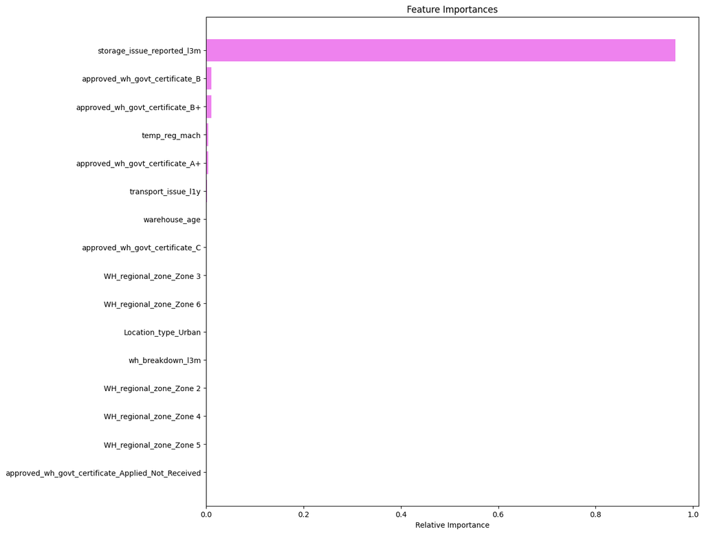

```python
feature_names = X_train.columns
importances = xgb_tuned.feature_importances_
indices = np.argsort(importances)

plt.figure(figsize=(12, 12))
plt.title("Feature Importances")
plt.barh(range(len(indices)), importances[indices], color="violet", align="center")
plt.yticks(range(len(indices)), [feature_names[i] for i in indices])
plt.xlabel("Relative Importance")
plt.show()
```

- Our model is highly reliant on one feature, which can be both a strength and a risk:
- If that feature is stable and well-measured, it drives excellent performance.
- If it’s noisy, missing, or changes over time, the model may degrade quickly

### Observed VS Predicted Values Plot of the test data for the best model, i.e., XGBOOST tuned Model

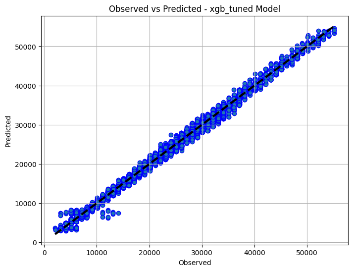

```python
# So plot observed and predicted values of the test data for the best model i.e. xg boost model
fig, ax = plt.subplots(figsize=(8, 6))
y_pred = xgb_tuned.predict(X_test)
ax.scatter(y_test, y_pred, edgecolors=(0, 0, 1))
ax.plot([y_test.min(), y_test.max()], [y_test.min(), y_test.max()], "k--", lw=3)
ax.set_xlabel("Observed")
ax.set_ylabel("Predicted")
ax.set_title("Observed vs Predicted - xgb_tuned Model")
plt.grid()
plt.show()
```

The tight clustering of points around the diagonal line indicates:

- Strong correlation between predicted and actual values
- High predictive accuracy
- Minimal bias or error
- No major outliers suggests the model generalizes well

**The model is reliable and well-calibrated, making it suitable for deployment or business reporting.**

# **Executive Summary**

We tested three advanced machine learning models — XGBoost, Random Forest, and Bagging — to predict warehouse performance using historical data. After tuning each model for accuracy and reliability, XGBoost emerged as the best performer.

- It consistently gave the most accurate predictions on unseen data.
- It explained over 99% of the variation in warehouse outcomes.
- It had the lowest error rates, meaning its predictions are close to reality. The model relies heavily on one key factor: whether storage issues were reported in the last 3 months. This single feature drives most of the predictive power.

# **Business Recommendations**

Prioritize Storage Issue Tracking, since recent storage issues are the strongest predictor of warehouse performance, ensure this data is captured accurately and consistently.

- Consider automating alerts or dashboards around this metric.
- Use the XGBoost Model for Forecasting
- Deploy the tuned XGBoost model to predict warehouse risk or performance.
- Integrate it into our reporting tools to support proactive decision-making.
- Simplify Data Collection as many other features (certifications, zones, equipment) had minimal impact.
- Focus data efforts on the few variables that truly matter — this reduces complexity and improves efficiency.
- Monitor Model Stability because the model depends heavily on one feature, keep an eye on its quality and consistency.
- Revalidate the model periodically to ensure it continues to perform well.
- Communicate Insights Clearly and share the model’s findings with warehouse managers and operations teams.
- Use simple visuals (like the observed vs predicted plot) to build trust and understanding.

This approach helps us move from reactive response to predictive, data-driven warehouse management — saving time, reducing risk, and improving service.